# Data Visualization Tutorial

#### ggplot

Again plot the cut on the x axis, but then `fill` using the second categorical variable. This has the effect of visualizing the **row** percents from the table above. The percent of color, within each type of cut.

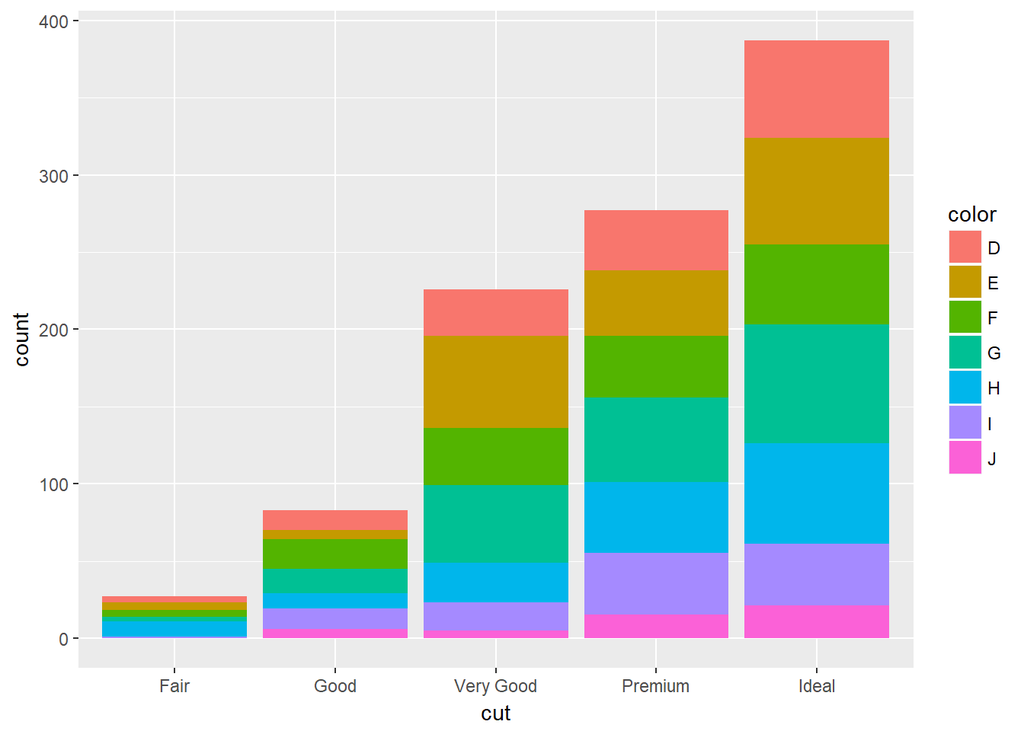

```r
ggplot(dsmall, aes(x=cut, fill=color)) + geom_bar()
```

Again the default is a stacked barchart. So we just specify `position=dodge` to put the bars side by side.

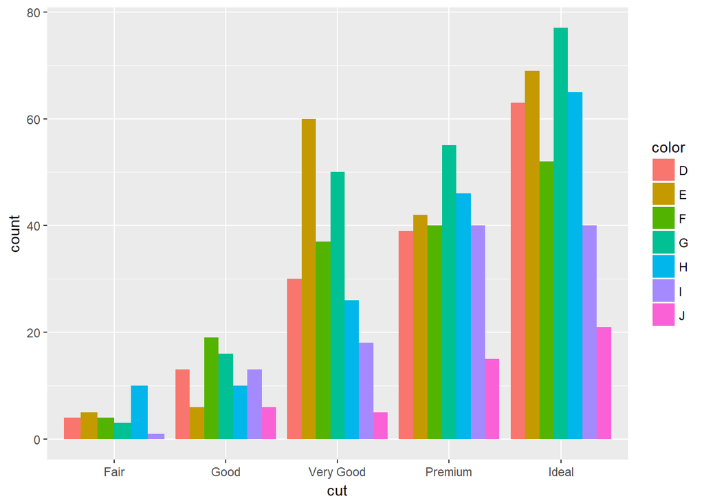

```r
ggplot(dsmall, aes(x=cut, fill=color)) + geom_bar(position = "dodge")
```

And look, an automatic legend. What if I wanted to better compare cut within color group? This is the **column** percentages. Just switch which variable is the x axis and which one is used to fill the colors!

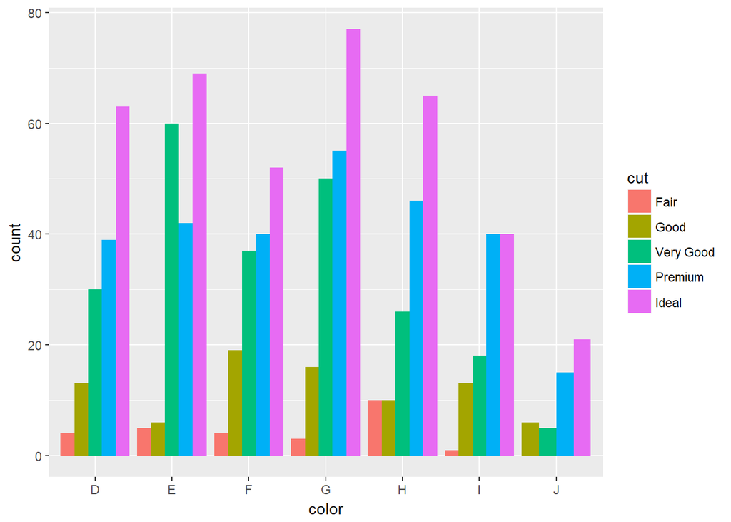

```r
ggplot(dsmall, aes(x=color, fill=cut)) + geom_bar(position = "dodge")
```

And this easy change is why we love `ggplot2`.

### Mosaic plots

But what if you want to know how two categorical variables are related and you don’t want to look at two different barplots? Mosaic plots are a way to visualize the proportions in a table. So here’s the two-way table we’ll be plotting.

```r
table(dsmall$cut, dsmall$color)
```

```
##
##              D  E  F  G  H  I  J
##   Fair       4  5  4  3 10  1  0
##   Good      13  6 19 16 10 13  6
##   Very Good 30 60 37 50 26 18  5
##   Premium   39 42 40 55 46 40 15
##   Ideal     63 69 52 77 65 40 21
```

The syntax for a mosiac plot uses *model notation*, which is basically y ~ x where the ~ is read as “twiddle” or “tilde”. It’s to the left of your **1** key.

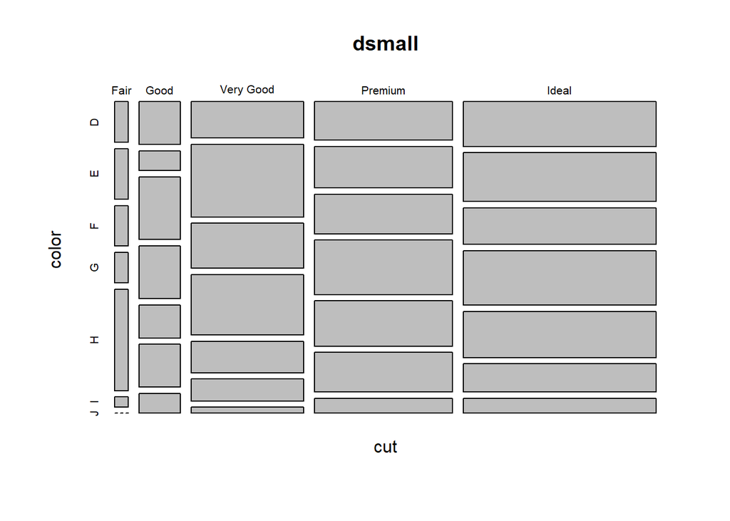

```r
mosaicplot(cut~color, data=dsmall)
```

Helpful, ish. Here are two very useful options. In reverse obviousness, `color` applies shades of gray to one of the factor levels, and `shade` applies a color gradient scale to the cells in order of what is less than expected (red) to what is more than expected (blue) if these two factors were compltely independent.

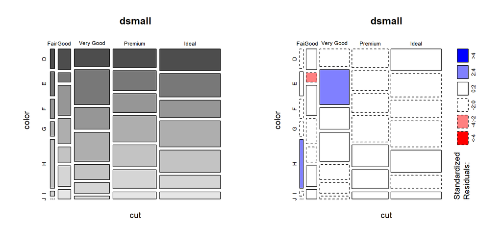

```r
par(mfrow=c(1,2)) # display the plots in 1 row and 2 columns
mosaicplot(cut~color, data=dsmall, color=TRUE)
mosaicplot(cut~color, data=dsmall, shade=TRUE)
```

That’s about all the ways you can plot categorical variables. If you are wondering why there was no 3D barcharts demonstrated see  
[here](http://faculty.atu.edu/mfinan/2043/section31.pdf), [here](http://www.bbc.co.uk/schools/gcsebitesize/maths/statistics/representingdata2rev5.shtml), and [here](https://en.wikipedia.org/wiki/Misleading_graph) for other ways you can really screw up your visualization.

## Continuous v. Continuous

### Scatterplot

The most common method of visualizing the relationship between two continuous variables is by using a scatterplot.

#### base

Back to the `plot()` command. Here we use model notation again, so it’s $y~x$.

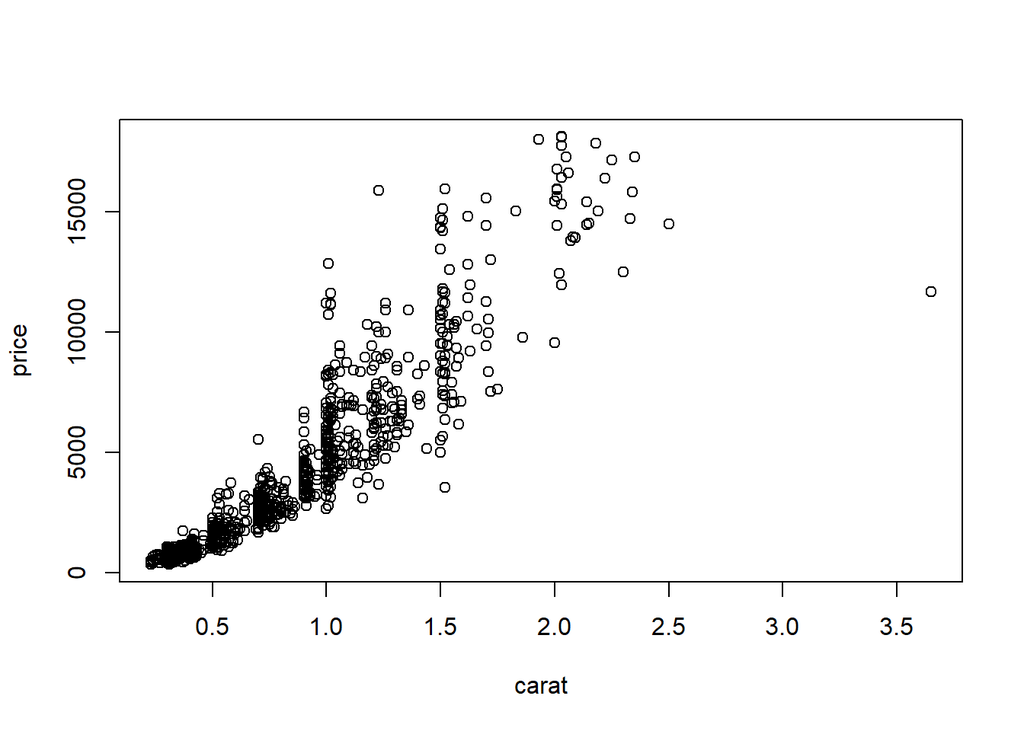

```r
plot(price~carat, data=dsmall)
```

Looks like for the most part as the carat value increases so does price. That makes sense.

#### ggplot

With ggplot we specify both the x and y variables, and add a point.

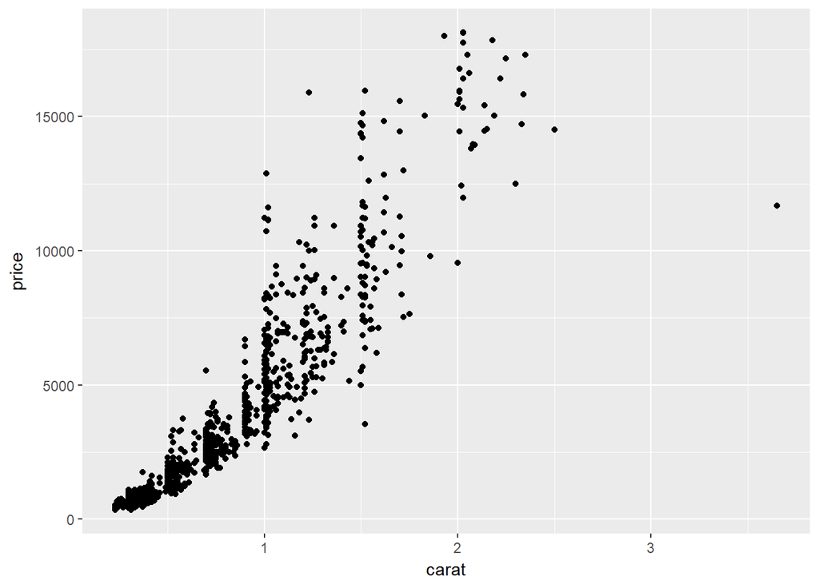

```r
ggplot(dsmall, aes(x=carat, y=price)) + geom_point()
```

## Scatterplot matrix

A scatterplot matrix allows you to look at the bivariate comparison of multiple pairs of variables simultaneously. First we need to trim down the data set to only include the variables we want to plot, then we use teh `pairs()` function.

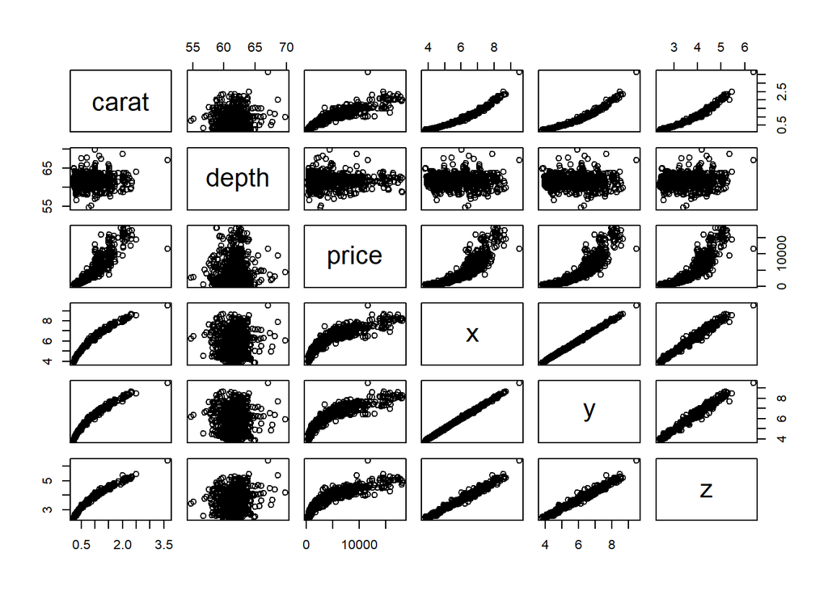

```r
c.vars <- dsmall[,c('carat', 'depth', 'price', 'x', 'y', 'z')]
pairs(c.vars)
```

We can see price has a non-linear relationship with X, Y and Z and x & y have a near perfect linear relationship.

**Other Resources** * http://www.statmethods.net/graphs/scatterplot.html * https://www.r-bloggers.com/scatterplot-matrices/

### Adding lines to the scatterplots

Two most common trend lines added to a scatterplots are the “best fit” straight line and the “lowess” smoother line.

#### base

The best fit line (in blue) gets added by using the `abline()` function wrapped around the linear model function `lm()`. Note it uses the same model notation syntax and the `data=` statement as the `plot()` function does. The lowess line is added using the `lines()` function, but the `lowess()` function itself doesn’t allow for the `data=` statement so we have to use `$` sign notation.

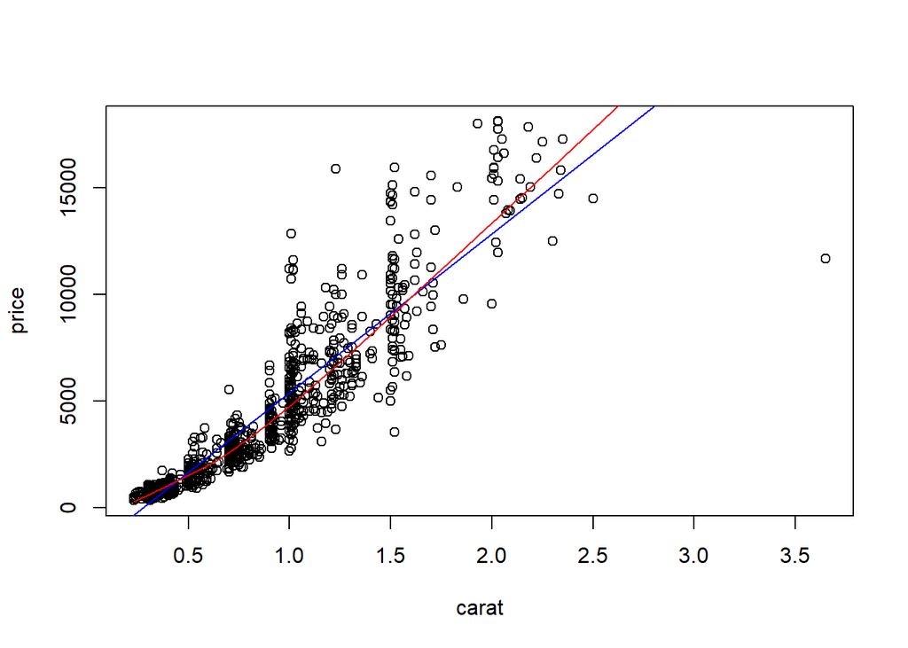

```r
plot(price~carat, data=dsmall)
abline(lm(price~carat, data=dsmall), col="blue")
lines(lowess(dsmall$price~dsmall$carat), col="red")
```

#### ggplot

With ggplot, we just add a `geom_smooth()` layer.

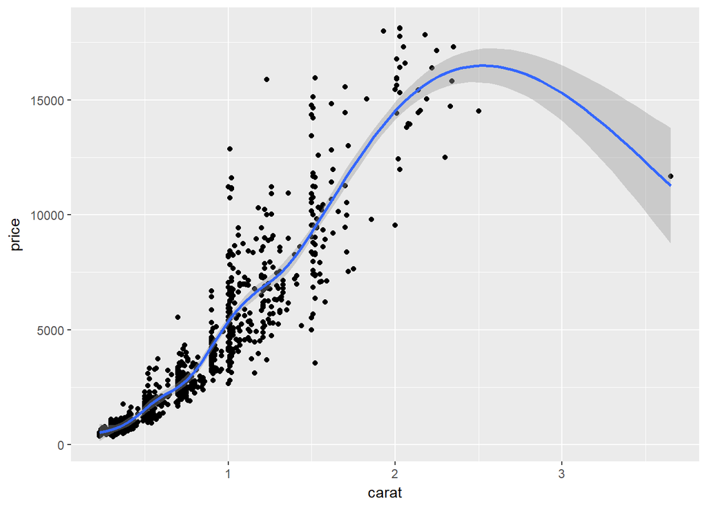

```r
ggplot(dsmall, aes(x=carat, y=price)) + geom_point() + geom_smooth()
```

Here the point-wise confidence interval for this lowess line is shown in grey. If you want to turn the confidence interval off, use `se=FALSE`. Also notice that the smoothing geom uses a different function or window than the `lowess` function used in base graphics.

Here it is again using the `ggplot` plotting function and adding another `geom_smooth()` layer for the `lm` (linear model) line in blue, and the lowess line (by not specifying a method) in red.

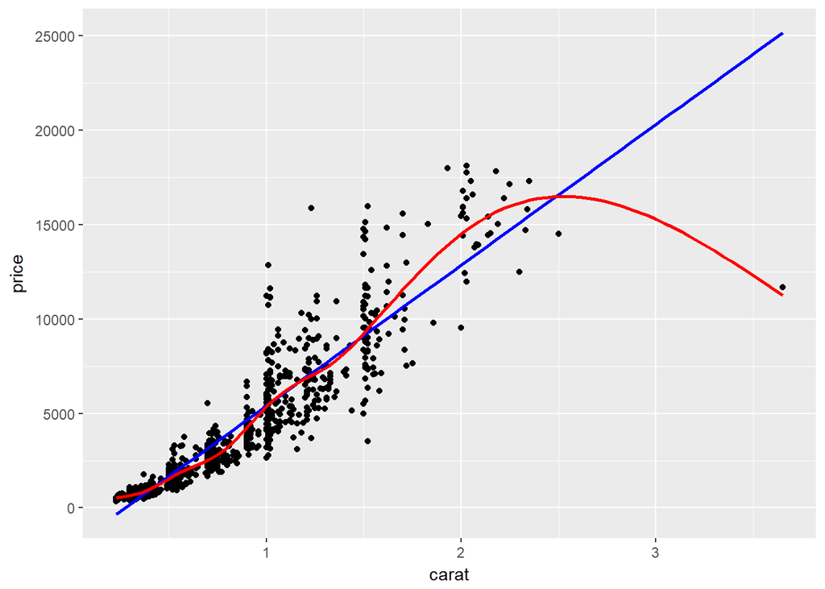

```r
ggplot(dsmall, aes(x=carat, y=price)) + geom_point() +
  geom_smooth(se=FALSE, method="lm", color="blue") +
  geom_smooth(se=FALSE, color="red")
```

## Line plots

Line plots connect each dot with a straight line.

We saw earlier that `carat` and `price` seemed possibly linear. Let see how the average price changes with carat.

```r
library(dplyr)
price.per.carat <- dsmall %>% group_by(carat) %>% summarise(mean = mean(price))
```

### base

For base graphics, type=‘b’ means both points and lines, ‘l’ gives you just lines and ‘p’ gives you only points. You can find more plotting character options under `?pch`.

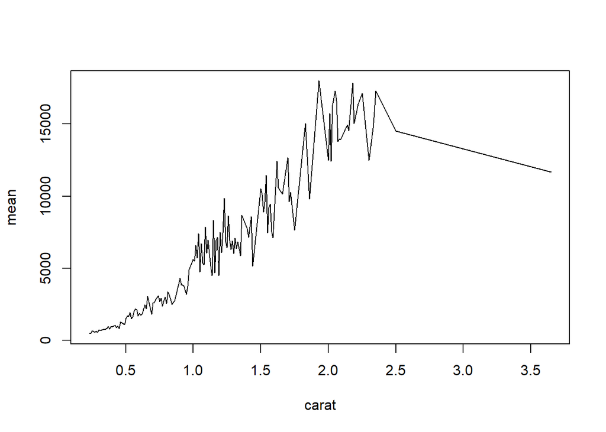

```r
plot(mean~carat, data=price.per.carat, type='l')
```

### ggplot

With ggplot we specify that we want a line geometry only.

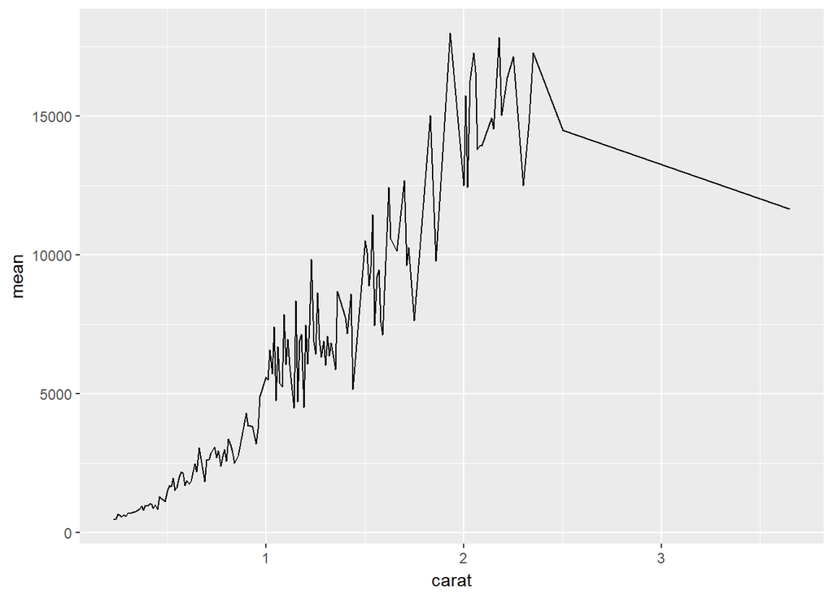

```r
ggplot(price.per.carat, aes(x=carat, y=mean)) + geom_line()
```

How does this relationship change with cut of the diamond? First lets get the average price per combiation of carat and cut.

```r
ppc2 <- dsmall %>% group_by(cut, carat) %>% summarise(mean = mean(price))
```

#### base

This plot can be created in base graphics, but it takes an advanced knowledge of the grahpics system to do so. So I do not show it here.

#### ggplot

This is where ggplot starts to excel in it’s ease of creating more complex plots. All we have to do is specify that we want the lines colored by the cut variable.

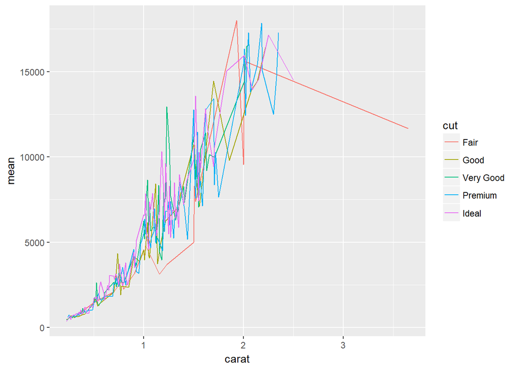

```r
ggplot(ppc2, aes(x=carat, y=mean, col=cut)) + geom_line()
```

And we get one line per cut.

## Continuous v. Categorical

Create an appropriate plot for a continuous variable, and plot it for each level of the categorical variable.

### Dotplot/strip chart

Dotplots can be very useful when plotting dots against several categories. They can also be called stripcharts.

#### base

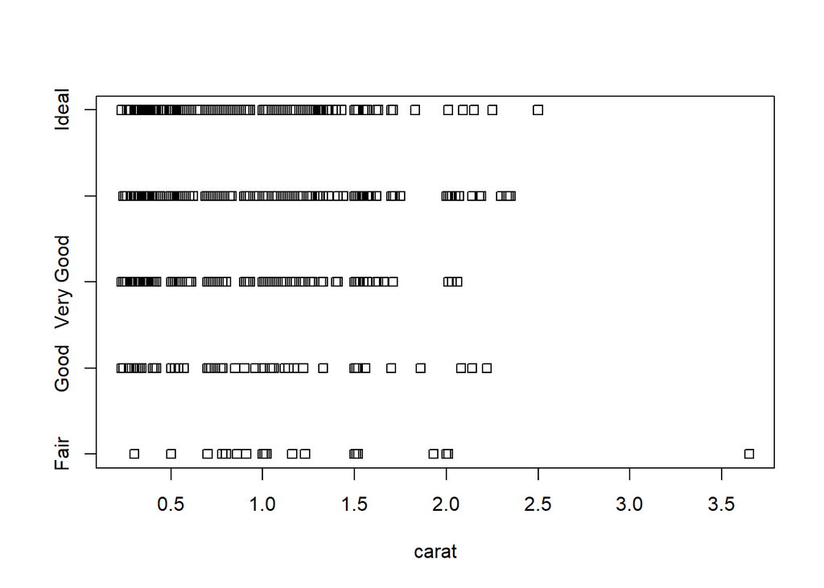

```r
stripchart(carat ~ cut, data=dsmall)
```

Doesn’t look to pretty, but kinda gets the point across. Few fair quality diamonds in the data set, pretty spread out across the carat range except one high end outlier.

#### ggplot

We can reproduce the same thing by plotting one continous variable against one categorical variable, and adding a layer of points. I’d argue that horizontal looks better due to the axis-labels.

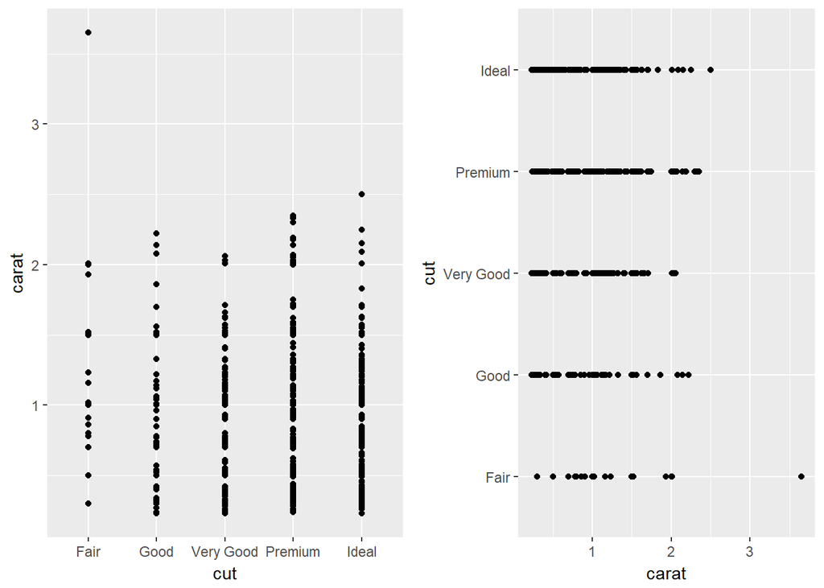

```r
a <- ggplot(dsmall, aes(y=carat, x=cut)) + geom_point()
b <- ggplot(dsmall, aes(y=cut, x=carat)) + geom_point()
grid.arrange(a, b, ncol=2)
```

### Grouped boxplots

#### base

Base graphics plots grouped boxplots with also just the addition of a twiddle (tilde) `~`. Another example of where model notation works.

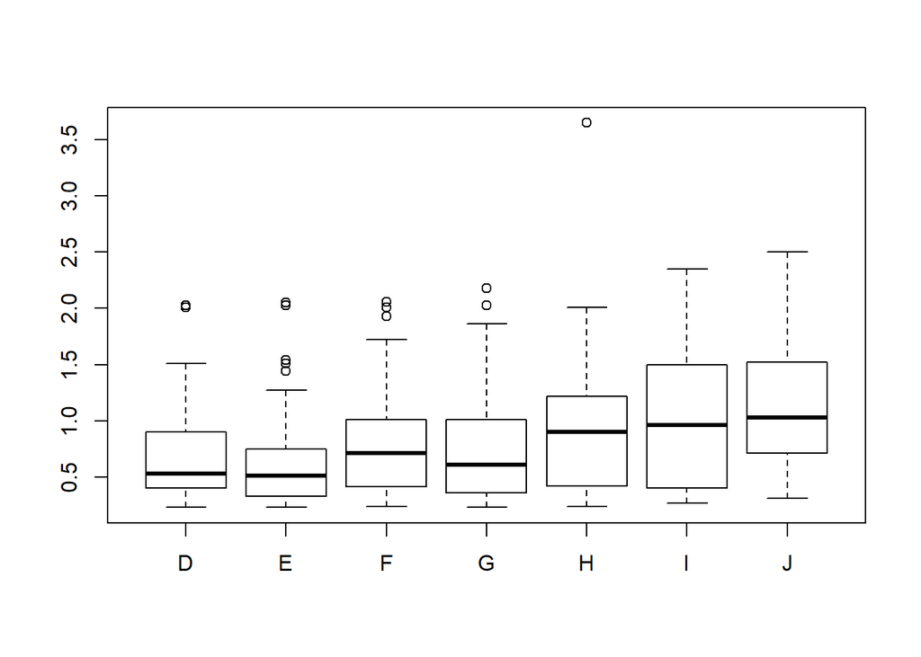

```r
boxplot(carat~color, data=dsmall)
```

#### ggplot

A simple addition, just define your x and y accordingly.

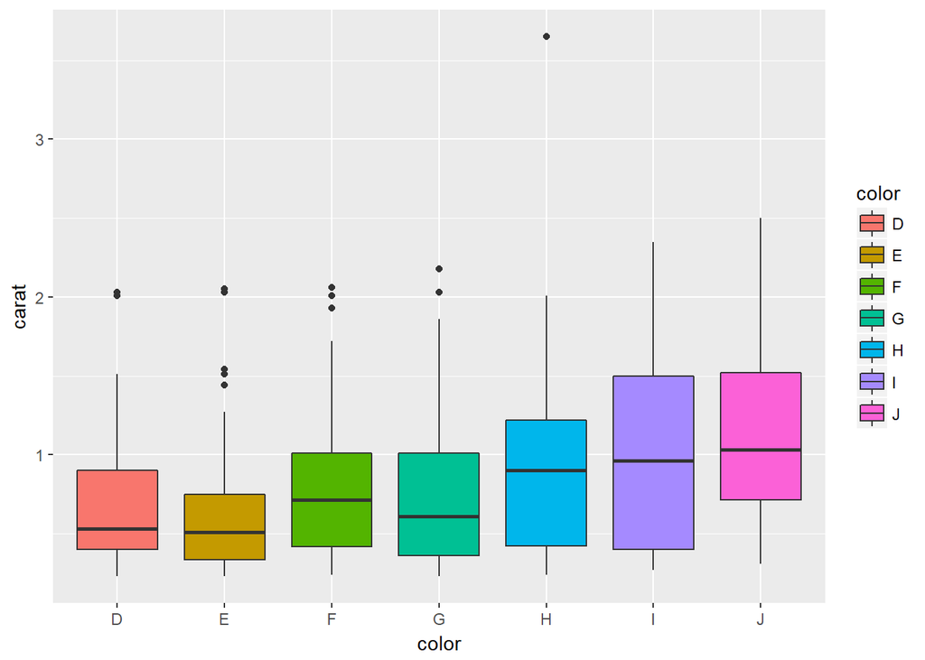

```r
ggplot(dsmall, aes(x=color, y=carat, fill=color)) + geom_boxplot()
```

#### Adding violins

Violin plots can be overlaid here as well.

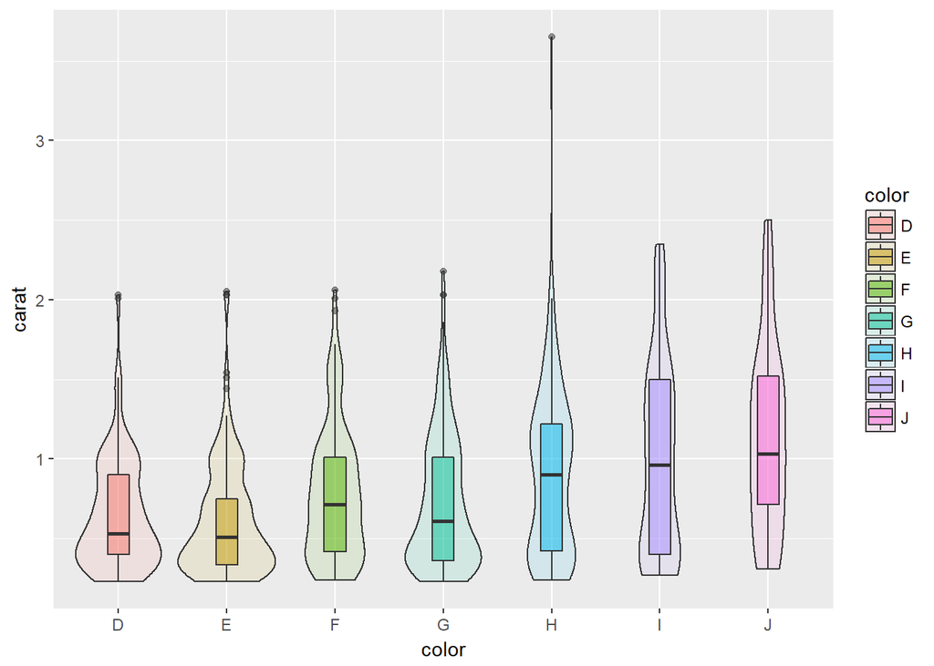

```r
ggplot(dsmall, aes(x=color, y=carat, fill=color)) +
        geom_violin(alpha=.1) +
        geom_boxplot(alpha=.5, width=.2)
```

### Grouped histograms

#### base

There is no easy way to create grouped histograms in base graphics we will skip it.

#### ggplot

By default ggplot wants to overlay all plots on the same grid. This doesn’t look to good with histograms. Instead you can overlay density plots

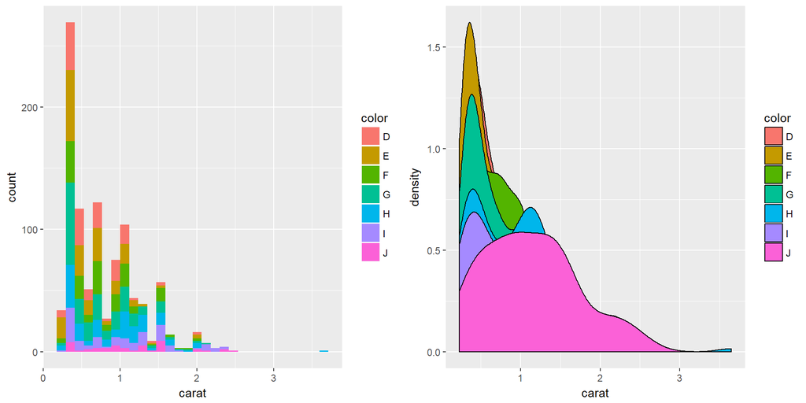

```r
a <- qplot(x=carat, data=dsmall, geom="histogram", fill=color)
b <- qplot(x=carat, data=dsmall, geom="density", fill=color)
grid.arrange(a,b, ncol=2)
```

The solid fills are still difficult to read, so we can either turn down the alpha (turn up the transparency) or only color the lines and not the fill.

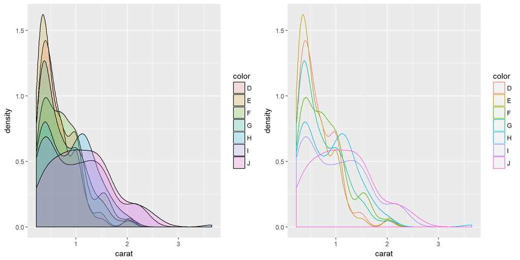

```r
c <- ggplot(dsmall, aes(x=carat, fill=color)) + geom_density(alpha=.2)
d <- ggplot(dsmall, aes(x=carat, col=color)) + geom_density()
grid.arrange(c,d, ncol=2)
```

# Joy plots

Hot off the press, gaining instant popularity this summer. They are a combination of a Cleveland dot plot and a density plot.

# Faceting / paneling

ggplot introduces yet another term called `faceting`. The definition is *a particular aspect or feature of something*, or *one side of something many-sided, especially of a cut gem*. Basically instead of plotting the grouped graphics on the same plotting area, we let each group have it’s own plot, or facet.

We add a `facet_wrap()` and specify that we want to panel on the color group. Note the twiddle in front of color.

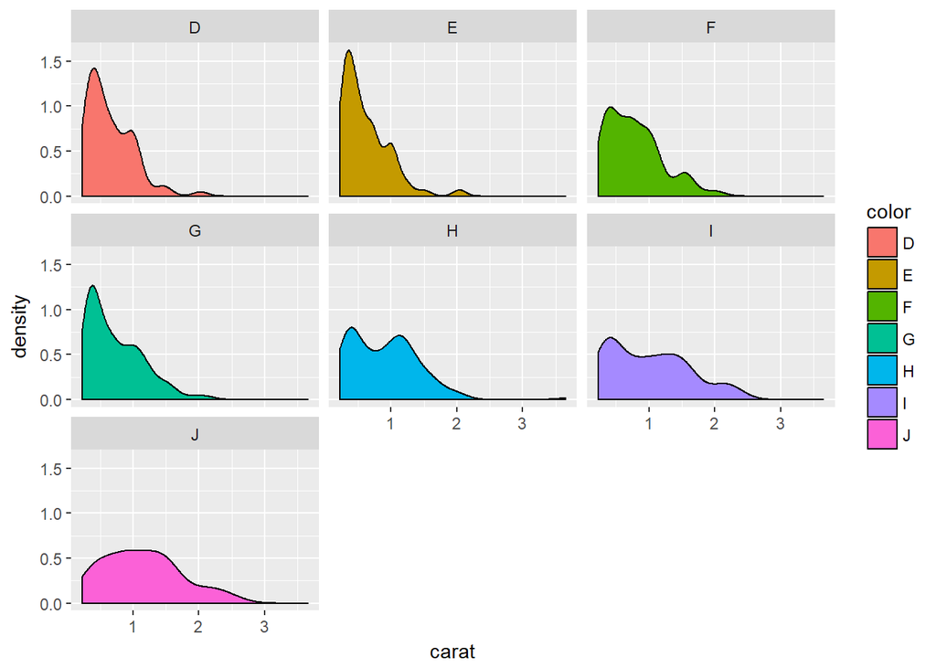

```r
ggplot(dsmall, aes(x=carat, fill=color)) + geom_density() + facet_wrap(~color)
```

The grid placement can be semi-controlled by using the `ncol` argument in the `facet_wrap()` statement.

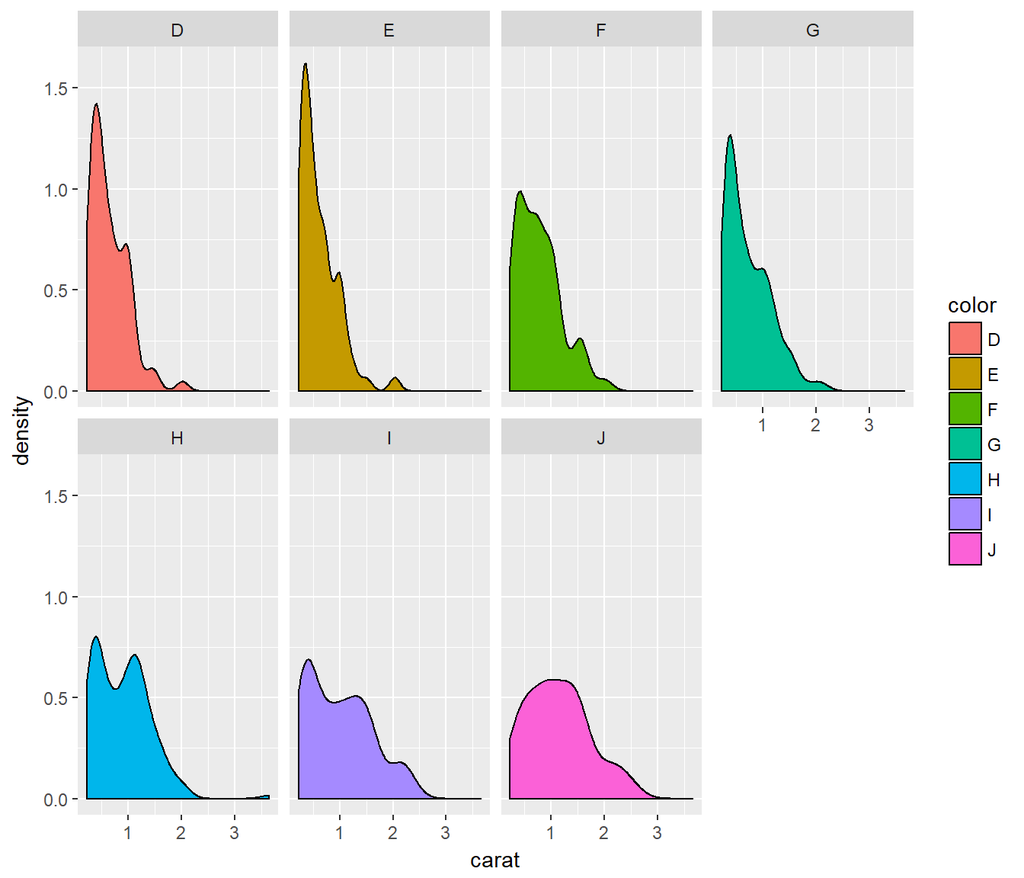

```r
ggplot(dsmall, aes(x=carat, fill=color)) + geom_density() + facet_wrap(~color, ncol=4)
```

It is important to compare distriubtions across groups on the same scale, and our eyes can compare items vertically better than horizontally. So let’s force `ncol=1`.

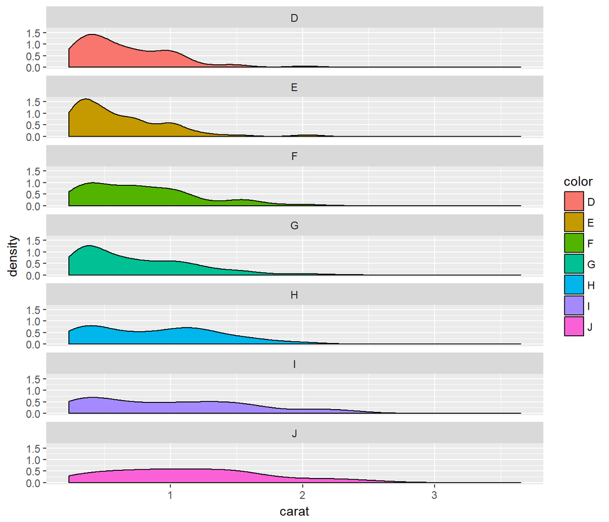

```r
ggplot(dsmall, aes(x=carat, fill=color)) + geom_density() + facet_wrap(~color, ncol=1)
```

## Other ways to get multiple plots per window

### base

I use `par(mfrow=c(r,c))` for base graphics, where `r` is the number of rows and `c` the number of columns.

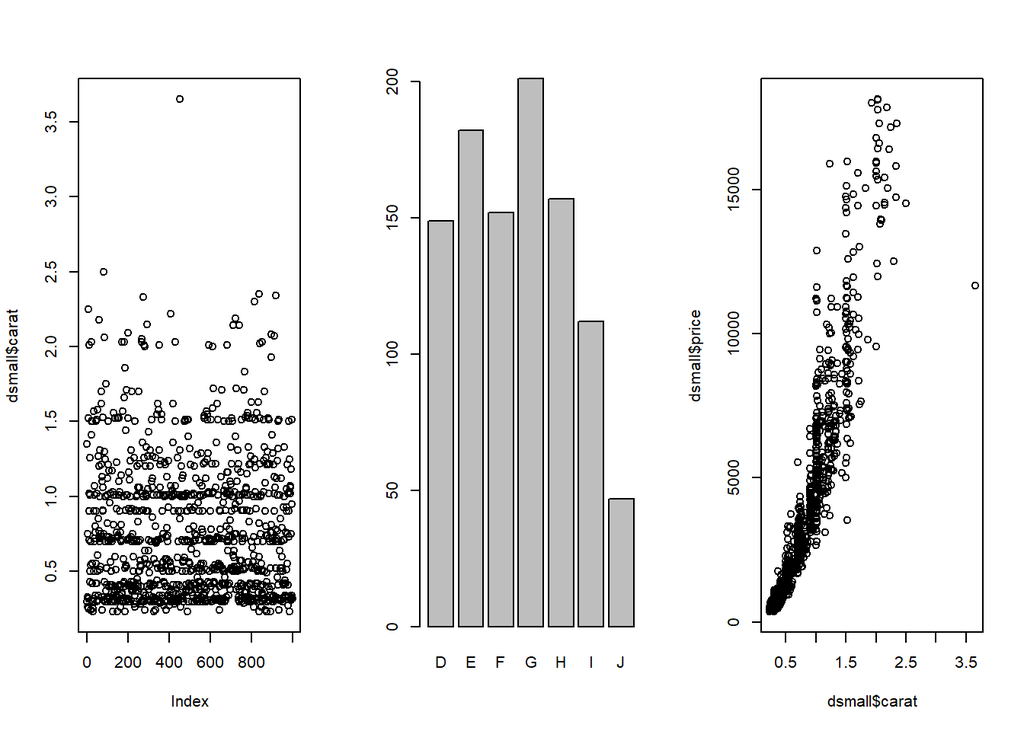

```r
par(mfrow=c(1,3))
plot(dsmall$carat)
plot(dsmall$color)
plot(dsmall$price ~ dsmall$carat)
```

Other resources including learning about `layouts`. Multipanel plotting with base graphics http://seananderson.ca/courses/11-multipanel/multipanel.pdf

#### ggplot

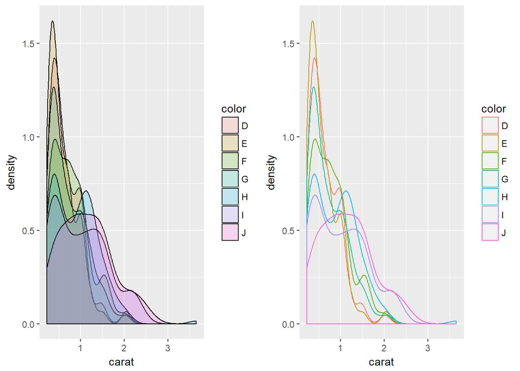

```r
a <- ggplot(dsmall, aes(x=carat, fill=color)) + geom_density(alpha=.2)
b <- ggplot(dsmall, aes(x=carat, col=color)) + geom_density()
grid.arrange(a,b, ncol=2)
```

# Multivariate (2+ variables)

This is not much more complicated than taking an appropriate bivariate plot and adding a third variable through paneling, coloring, or changing a shape.

This is trivial to do in ggplot, not trivial in base graphics. So I won’t show those examples.

## Three continuous

Continuous variables can also be mapped to the size of the point. Here I set the alpha on the points so we could see the overplotting (many points on a single spot). So the darker the spot the more data points on that spot.

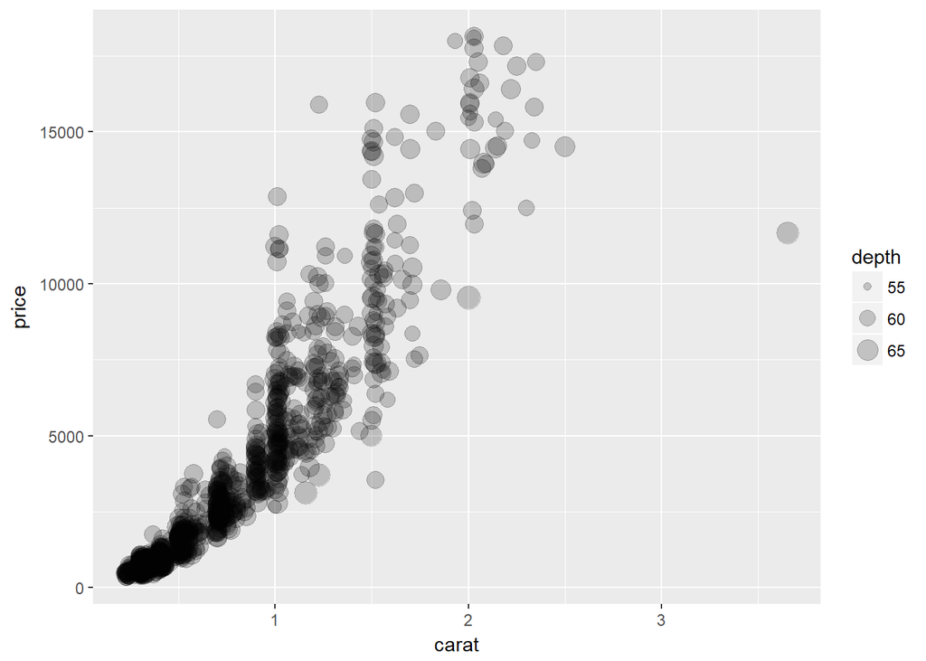

```r
ggplot(dsmall, aes(x=carat, y=price, size=depth)) + geom_point(alpha=.2)
```

## Two categorical and one continuous

This is very similar to side by side boxplots, one violin plot per `cut`, within each level of color. This is difficult to really see due to the large number of categories each factor has.

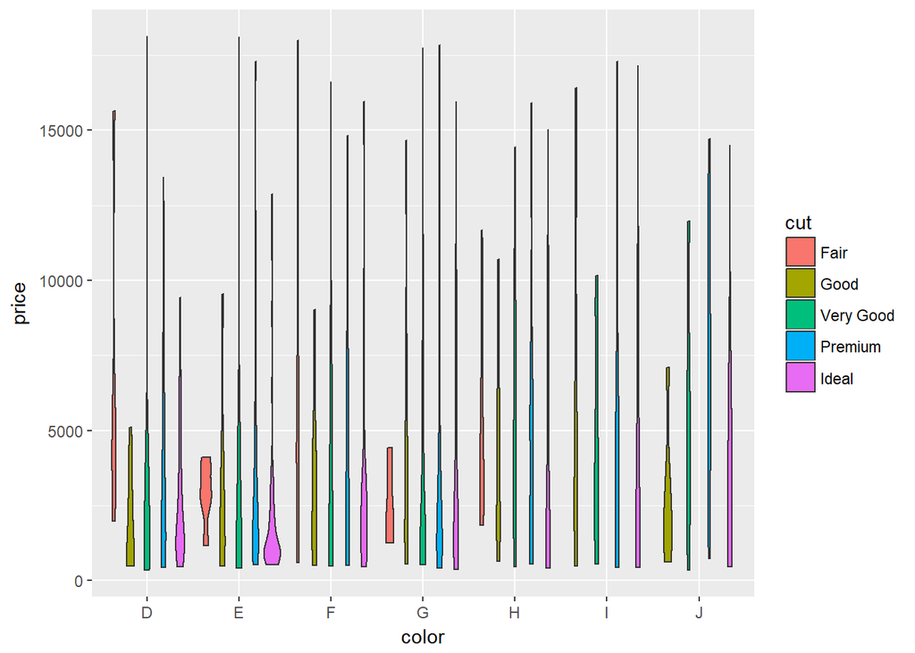

```r
ggplot(dsmall, aes(x=color, y=price, fill=cut)) + geom_violin()
```

Best bet here would be to panel on color and change the x axis to cut.

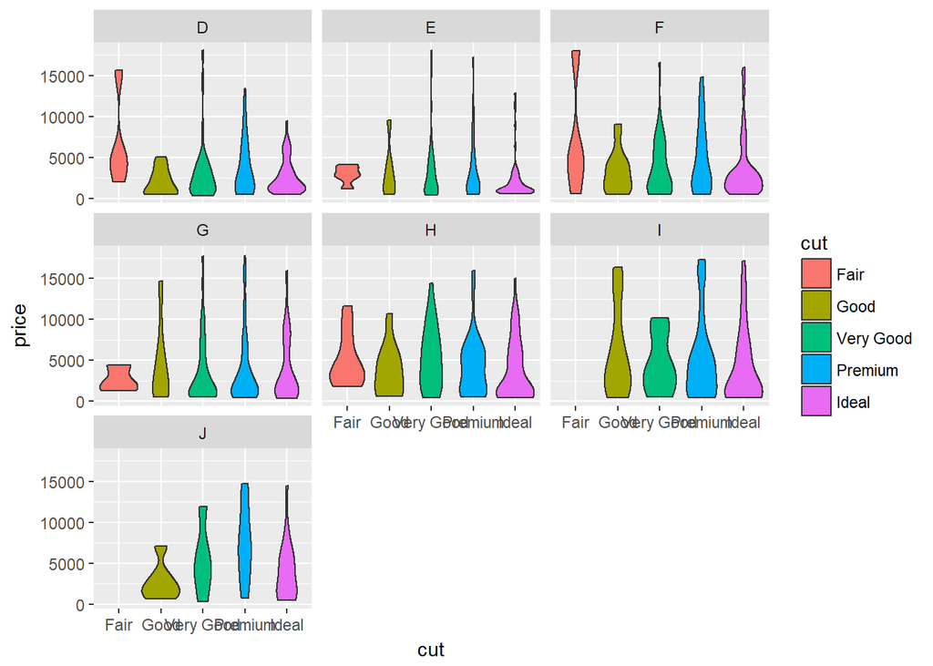

```r
ggplot(dsmall, aes(x=cut, y=price, fill=cut)) + geom_violin() + facet_wrap(~color)
```

## Two continuous and one categorical

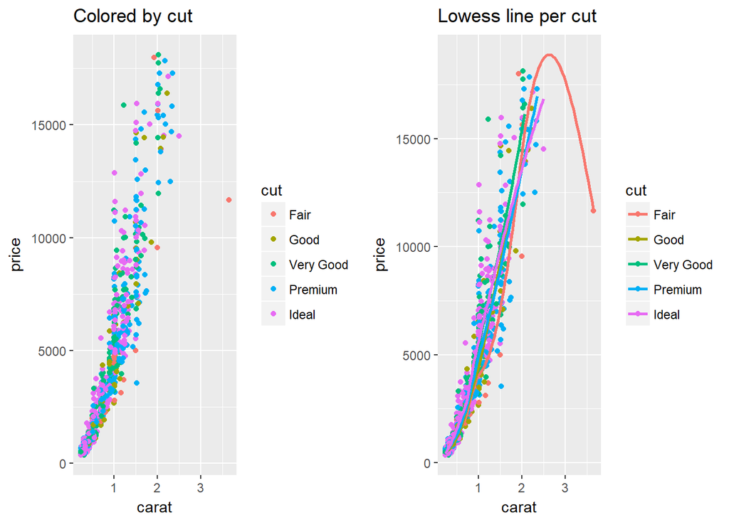

```r
a <- ggplot(dsmall, aes(x=carat, y=price, color=cut)) + geom_point() + ggtitle("Colored by cut")
d <- ggplot(dsmall, aes(x=carat, y=price, color=cut)) + geom_point() +
      geom_smooth(se=FALSE) +ggtitle("Lowess line per cut")
grid.arrange(a, d, nrow=1)
```

Change the shape

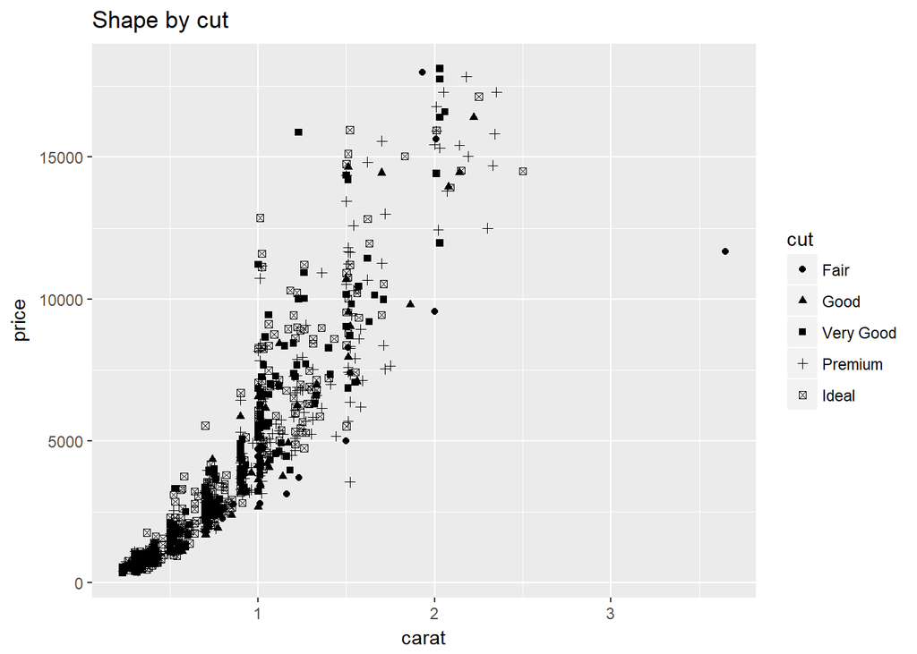

```r
ggplot(dsmall, aes(x=carat, y=price, shape=cut)) + geom_point() + ggtitle("Shape by cut")
```

Or we just panel by the third variable

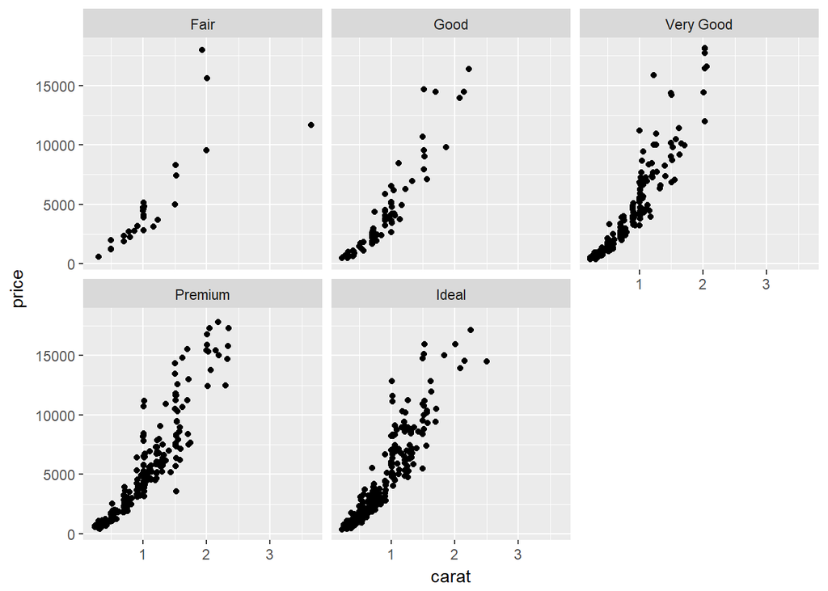

```r
ggplot(dsmall, aes(x=carat, y=price)) + geom_point() + facet_wrap(~cut)
```

## Paneling on two variables

Who says we’re stuck with only faceting on one variable? A varient on `facet_wrap` is `facet_grid`. Here we can specify multiple variables to panel on.

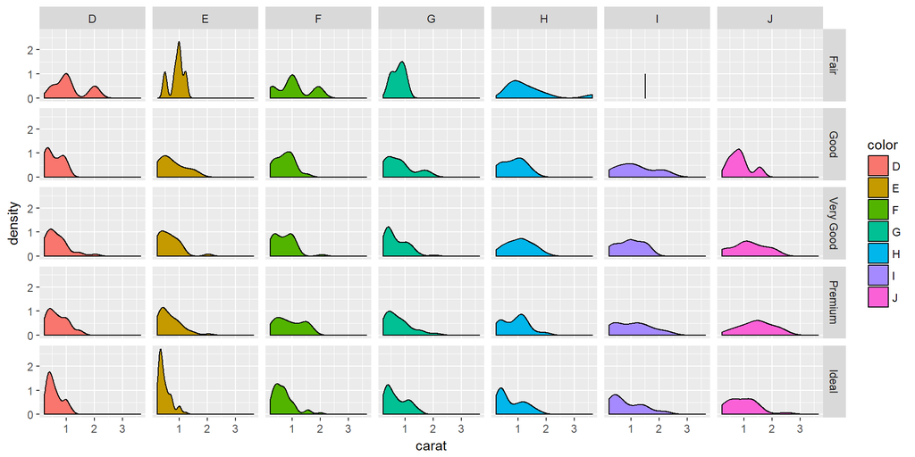

```r
ggplot(dsmall, aes(x=carat, fill=color)) + geom_density() + facet_grid(cut~color)
```

How about plotting price against caret, for all combinations of color and clarity, with the points further separated by cut?

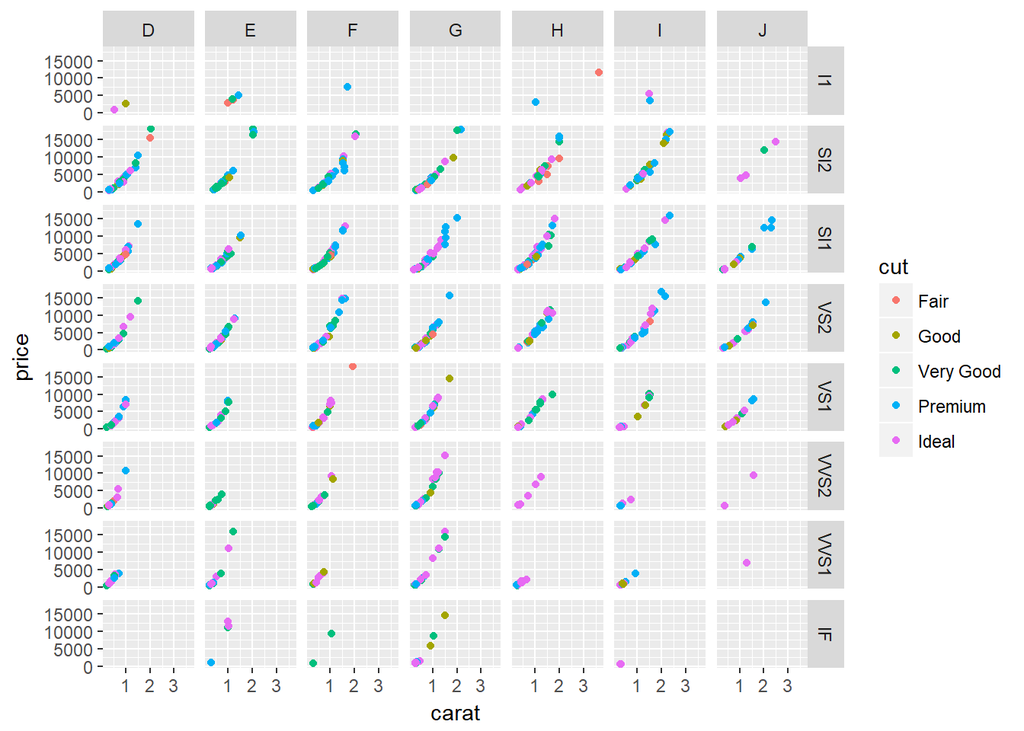

```r
ggplot(dsmall, aes(x=carat, y=price, color=cut)) + geom_point() + facet_grid(clarity~color)
```

And lastly let’s look back at how we can play with scatterplots of using a third categorical variable (using `ggplot2` only). We can color the points by cut,

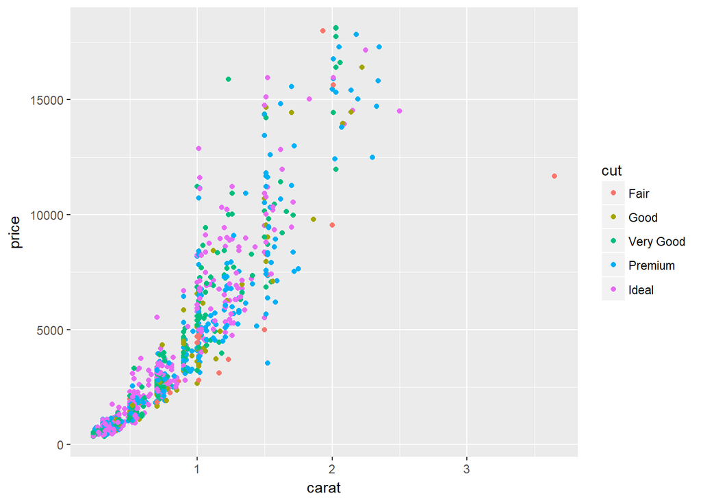

```r
ggplot(dsmall, aes(x=carat, y=price, color=cut)) + geom_point()
```

We could add a smoothing lowess line for each cut separately,

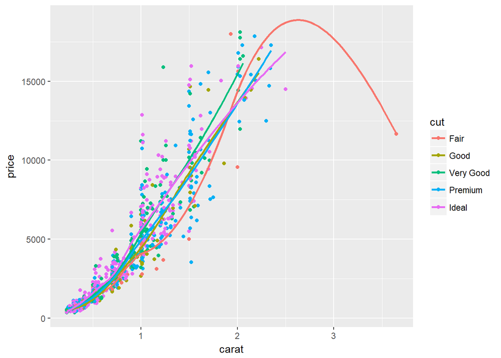

```r
ggplot(dsmall, aes(x=carat, y=price, color=cut)) + geom_point() + geom_smooth(se=FALSE)
```

We could change the color by clarity, and shape by cut.

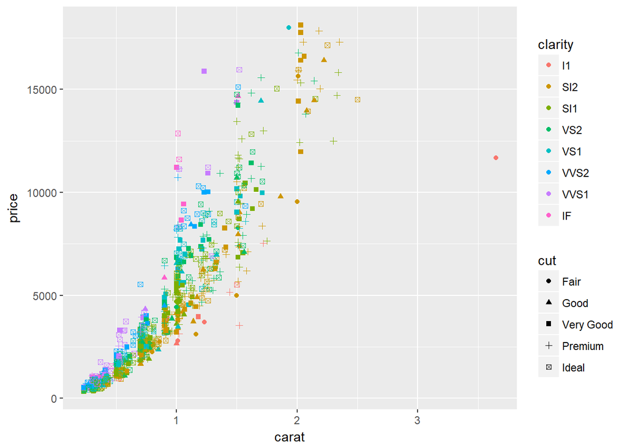

```r
ggplot(dsmall, aes(x=carat, y=price, color=clarity, shape=cut)) + geom_point()
```

That’s pretty hard to read. So note that just because you **can** change an aestetic, doesn’t mean you should. And just because you can plot things on the same axis, doesn’t mean you have to.

Before you share your plot with any other eyes, always take a step back and try to expain what it is telling you. If you have to take more than a minute to get to the point then it may be too complex and simpler graphics are likely warranted.

# But what about…

- Legend adjustment: remove it, move it to another side, rename it
- Custom specified colors and shapes

Go here http://www.cookbook-r.com/Graphs/ for these. This tutorial is long enough.

# Other plots not mentioned

- Heat maps https://www.r-bloggers.com/how-to-make-a-simple-heatmap-in-ggplot2/
- Word clouds https://rpubs.com/brandonkopp/creating-word-clouds-in-r , simpler: http://dangoldin.com/2016/06/06/word-clouds-in-r/
- Interactive plots - Look into `plotly()` and `ggplotly()`
- the circle type plots

# Additional Resources

For any Google Search - be sure to limit searches to within the past year or so. R packages get updated very frequently, and many functions change or become obsolete.

- R Graphics: https://www.stat.auckland.ac.nz/~paul/RGraphics/rgraphics.html The best book about using base graphics
- R Graphics Cookbook: http://www.cookbook-r.com/Graphs/ or http://amzn.com/1449316956 The best book for using ggplot2
- STHDA: Statisical tools for high-throughput data analysis. http://www.sthda.com/english/
- Quick-R: [Basic Graphs](http://www.statmethods.net/graphs/index.html)
- Quick-R: [ggplot2](http://www.statmethods.net/advgraphs/ggplot2.html)
- Books
  - ggplot2 http://ggplot2.org/book/ or http://amzn.com/0387981403
  - qplot http://ggplot2.org/book/qplot.pdf
- Help lists
  - ggplot2 mailing list http://groups.google.com/group/ggplot2
  - stackoverflow http://stackoverflow.com/tags/ggplot2
  - Chico R users group